# Risk Factor Analysis

## Outcome Variable

**Outcome Variable:** haz

## Predictor Variables

**Intervention Variable:** fhtcm

**Adjustment Set:**

- arm
- W_mage
- W_fage
- meducyrs
- feducyrs
- W_mhtcm
- W_mwtkg
- W_mbmi
- single
- W_gagebrth
- W_birthwt
- W_birthlen
- vagbrth
- delta_W_mage
- delta_W_fage
- delta_meducyrs
- delta_feducyrs
- delta_W_mhtcm
- delta_W_mwtkg
- delta_W_mbmi
- delta_single
- delta_W_gagebrth
- delta_W_birthwt
- delta_W_birthlen
- delta_vagbrth

## Stratifying Variables

The analysis was stratified on these variable(s):

- agecat
- studyid
- country

## Data Summary

| agecat | studyid | country | fhtcm | n_cell | n |
| --- | --- | --- | --- | --- | --- |
| 6 months | ki1000304b-SAS-CompFeed | INDIA | >=167 cm | 369 | 807 |
| 6 months | ki1000304b-SAS-CompFeed | INDIA | <162 cm | 194 | 807 |
| 6 months | ki1000304b-SAS-CompFeed | INDIA | [162-167) cm | 244 | 807 |
| 6 months | ki1000304b-SAS-FoodSuppl | INDIA | >=167 cm | 102 | 372 |
| 6 months | ki1000304b-SAS-FoodSuppl | INDIA | <162 cm | 148 | 372 |
| 6 months | ki1000304b-SAS-FoodSuppl | INDIA | [162-167) cm | 122 | 372 |
| 6 months | ki1101329-Keneba | GAMBIA | >=167 cm | 979 | 1511 |
| 6 months | ki1101329-Keneba | GAMBIA | <162 cm | 113 | 1511 |
| 6 months | ki1101329-Keneba | GAMBIA | [162-167) cm | 419 | 1511 |
| 6 months | ki1119695-PROBIT | BELARUS | >=167 cm | 11146 | 11895 |
| 6 months | ki1119695-PROBIT | BELARUS | <162 cm | 156 | 11895 |
| 6 months | ki1119695-PROBIT | BELARUS | [162-167) cm | 593 | 11895 |
| 6 months | ki1135781-COHORTS | GUATEMALA | >=167 cm | 45 | 336 |
| 6 months | ki1135781-COHORTS | GUATEMALA | <162 cm | 197 | 336 |
| 6 months | ki1135781-COHORTS | GUATEMALA | [162-167) cm | 94 | 336 |
| 24 months | ki1101329-Keneba | GAMBIA | >=167 cm | 821 | 1297 |
| 24 months | ki1101329-Keneba | GAMBIA | <162 cm | 97 | 1297 |
| 24 months | ki1101329-Keneba | GAMBIA | [162-167) cm | 379 | 1297 |
| 24 months | ki1119695-PROBIT | BELARUS | >=167 cm | 3445 | 3670 |
| 24 months | ki1119695-PROBIT | BELARUS | <162 cm | 53 | 3670 |
| 24 months | ki1119695-PROBIT | BELARUS | [162-167) cm | 172 | 3670 |
| 24 months | ki1135781-COHORTS | GUATEMALA | >=167 cm | 72 | 528 |
| 24 months | ki1135781-COHORTS | GUATEMALA | <162 cm | 307 | 528 |
| 24 months | ki1135781-COHORTS | GUATEMALA | [162-167) cm | 149 | 528 |

The following strata were considered:

- agecat: 24 months, studyid: ki1101329-Keneba, country: GAMBIA
- agecat: 24 months, studyid: ki1119695-PROBIT, country: BELARUS
- agecat: 24 months, studyid: ki1135781-COHORTS, country: GUATEMALA
- agecat: 6 months, studyid: ki1000304b-SAS-CompFeed, country: INDIA
- agecat: 6 months, studyid: ki1000304b-SAS-FoodSuppl, country: INDIA
- agecat: 6 months, studyid: ki1101329-Keneba, country: GAMBIA
- agecat: 6 months, studyid: ki1119695-PROBIT, country: BELARUS
- agecat: 6 months, studyid: ki1135781-COHORTS, country: GUATEMALA

## Methods Detail

We’re interested in the causal parameters $E[Y_a]$ for all values of $a \in \mathcal{A}$. These parameters represent the mean outcome if, possibly contrary to fact, we intervened to set all units to have $A=a$. Under the randomization and positivity assumptions, these are identified by the statistical parameters $\psi_a=E_W[E_{Y|A,W}(Y|A=a,W)]$. In addition, we’re interested in the mean of $Y$, $E[Y]$ under no intervention (the observed mean). We will estimate these parameters by using SuperLearner to fit the relevant likelihood factors – $E_{Y|A,W}(Y|A=a,W)$ and $p(A=a|W)$, and then updating our likelihood fit using a joint TMLE.

For unadjusted analyses ($W=\{\}$), initial likelihoods were estimated using Lrnr_glm to estimate the simple $E(Y|A)$ and Lrnr_mean to estimate $p(A)$. For adjusted analyses, a small library containing Lrnr_glmnet, Lrnr_xgboost, and Lrnr_mean was used.

# Results Detail

## Results Plots

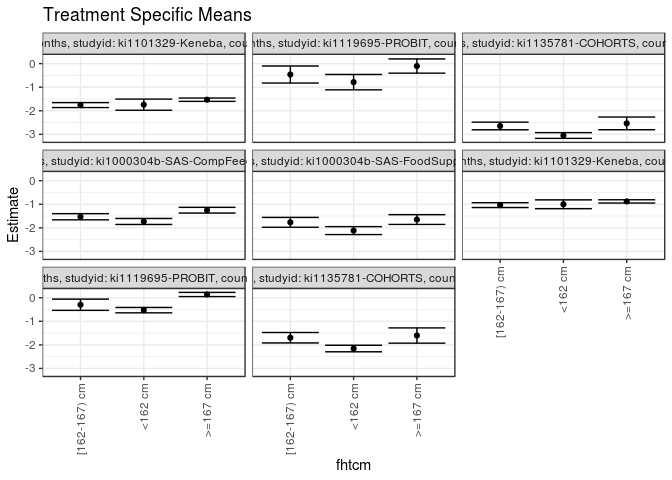

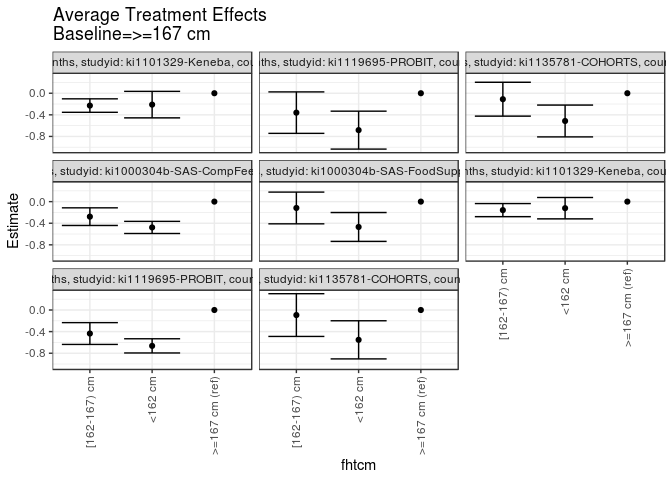

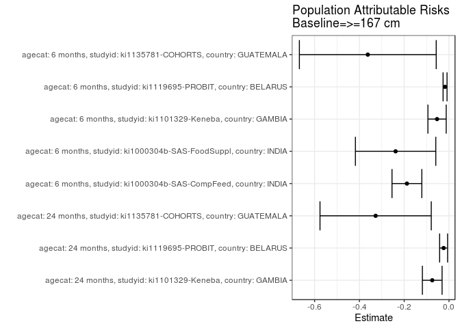

## Results Table

### Parameter: TSM

| agecat | studyid | country | intervention_level | baseline_level | estimate | ci_lower | ci_upper |
| --- | --- | --- | --- | --- | --- | --- | --- |
| 6 months | ki1000304b-SAS-CompFeed | INDIA | >=167 cm | NA | -1.2522183 | -1.3736784 | -1.1307581 |
| 6 months | ki1000304b-SAS-CompFeed | INDIA | <162 cm | NA | -1.7300584 | -1.8574818 | -1.6026351 |
| 6 months | ki1000304b-SAS-CompFeed | INDIA | [162-167) cm | NA | -1.5304470 | -1.6613287 | -1.3995652 |
| 6 months | ki1000304b-SAS-FoodSuppl | INDIA | >=167 cm | NA | -1.6487661 | -1.8554587 | -1.4420735 |
| 6 months | ki1000304b-SAS-FoodSuppl | INDIA | <162 cm | NA | -2.1180137 | -2.2864240 | -1.9496034 |
| 6 months | ki1000304b-SAS-FoodSuppl | INDIA | [162-167) cm | NA | -1.7662537 | -1.9749586 | -1.5575487 |
| 6 months | ki1101329-Keneba | GAMBIA | >=167 cm | NA | -0.8788746 | -0.9476258 | -0.8101233 |
| 6 months | ki1101329-Keneba | GAMBIA | <162 cm | NA | -1.0002437 | -1.1869440 | -0.8135433 |
| 6 months | ki1101329-Keneba | GAMBIA | [162-167) cm | NA | -1.0360936 | -1.1387578 | -0.9334294 |
| 6 months | ki1119695-PROBIT | BELARUS | >=167 cm | NA | 0.1379265 | 0.0495302 | 0.2263227 |
| 6 months | ki1119695-PROBIT | BELARUS | <162 cm | NA | -0.5261084 | -0.6398151 | -0.4124017 |
| 6 months | ki1119695-PROBIT | BELARUS | [162-167) cm | NA | -0.2976865 | -0.5361749 | -0.0591980 |
| 6 months | ki1135781-COHORTS | GUATEMALA | >=167 cm | NA | -1.6028228 | -1.9269798 | -1.2786657 |
| 6 months | ki1135781-COHORTS | GUATEMALA | <162 cm | NA | -2.1551794 | -2.2939992 | -2.0163596 |
| 6 months | ki1135781-COHORTS | GUATEMALA | [162-167) cm | NA | -1.6964582 | -1.9177928 | -1.4751237 |
| 24 months | ki1101329-Keneba | GAMBIA | >=167 cm | NA | -1.5300289 | -1.6005724 | -1.4594854 |
| 24 months | ki1101329-Keneba | GAMBIA | <162 cm | NA | -1.7407327 | -1.9762332 | -1.5052322 |
| 24 months | ki1101329-Keneba | GAMBIA | [162-167) cm | NA | -1.7583447 | -1.8631219 | -1.6535675 |
| 24 months | ki1119695-PROBIT | BELARUS | >=167 cm | NA | -0.1025772 | -0.4043794 | 0.1992249 |
| 24 months | ki1119695-PROBIT | BELARUS | <162 cm | NA | -0.7855904 | -1.1119575 | -0.4592233 |
| 24 months | ki1119695-PROBIT | BELARUS | [162-167) cm | NA | -0.4619219 | -0.8237397 | -0.1001041 |
| 24 months | ki1135781-COHORTS | GUATEMALA | >=167 cm | NA | -2.5353366 | -2.8044259 | -2.2662473 |
| 24 months | ki1135781-COHORTS | GUATEMALA | <162 cm | NA | -3.0492526 | -3.1705098 | -2.9279954 |
| 24 months | ki1135781-COHORTS | GUATEMALA | [162-167) cm | NA | -2.6456731 | -2.8077734 | -2.4835728 |

### Parameter: E(Y)

| agecat | studyid | country | intervention_level | baseline_level | estimate | ci_lower | ci_upper |
| --- | --- | --- | --- | --- | --- | --- | --- |
| 6 months | ki1000304b-SAS-CompFeed | INDIA | NA | NA | -1.4400743 | -1.5370187 | -1.3431300 |
| 6 months | ki1000304b-SAS-FoodSuppl | INDIA | NA | NA | -1.8871505 | -1.9993302 | -1.7749709 |
| 6 months | ki1101329-Keneba | GAMBIA | NA | NA | -0.9321551 | -0.9872314 | -0.8770788 |
| 6 months | ki1119695-PROBIT | BELARUS | NA | NA | 0.1203779 | 0.0296502 | 0.2111056 |
| 6 months | ki1135781-COHORTS | GUATEMALA | NA | NA | -1.9652976 | -2.0794998 | -1.8510954 |
| 24 months | ki1101329-Keneba | GAMBIA | NA | NA | -1.6048736 | -1.6613661 | -1.5483810 |
| 24 months | ki1119695-PROBIT | BELARUS | NA | NA | -0.1266303 | -0.4286611 | 0.1754004 |
| 24 months | ki1135781-COHORTS | GUATEMALA | NA | NA | -2.8628788 | -2.9576712 | -2.7680864 |

### Parameter: ATE

| agecat | studyid | country | intervention_level | baseline_level | estimate | ci_lower | ci_upper |
| --- | --- | --- | --- | --- | --- | --- | --- |
| 6 months | ki1000304b-SAS-CompFeed | INDIA | >=167 cm | >=167 cm | 0.0000000 | 0.0000000 | 0.0000000 |
| 6 months | ki1000304b-SAS-CompFeed | INDIA | <162 cm | >=167 cm | -0.4778402 | -0.5900324 | -0.3656479 |
| 6 months | ki1000304b-SAS-CompFeed | INDIA | [162-167) cm | >=167 cm | -0.2782287 | -0.4415167 | -0.1149407 |
| 6 months | ki1000304b-SAS-FoodSuppl | INDIA | >=167 cm | >=167 cm | 0.0000000 | 0.0000000 | 0.0000000 |
| 6 months | ki1000304b-SAS-FoodSuppl | INDIA | <162 cm | >=167 cm | -0.4692476 | -0.7365224 | -0.2019728 |
| 6 months | ki1000304b-SAS-FoodSuppl | INDIA | [162-167) cm | >=167 cm | -0.1174875 | -0.4115850 | 0.1766099 |
| 6 months | ki1101329-Keneba | GAMBIA | >=167 cm | >=167 cm | 0.0000000 | 0.0000000 | 0.0000000 |
| 6 months | ki1101329-Keneba | GAMBIA | <162 cm | >=167 cm | -0.1213691 | -0.3192069 | 0.0764687 |
| 6 months | ki1101329-Keneba | GAMBIA | [162-167) cm | >=167 cm | -0.1572190 | -0.2787088 | -0.0357293 |
| 6 months | ki1119695-PROBIT | BELARUS | >=167 cm | >=167 cm | 0.0000000 | 0.0000000 | 0.0000000 |
| 6 months | ki1119695-PROBIT | BELARUS | <162 cm | >=167 cm | -0.6640349 | -0.7954424 | -0.5326274 |
| 6 months | ki1119695-PROBIT | BELARUS | [162-167) cm | >=167 cm | -0.4356129 | -0.6375165 | -0.2337093 |
| 6 months | ki1135781-COHORTS | GUATEMALA | >=167 cm | >=167 cm | 0.0000000 | 0.0000000 | 0.0000000 |
| 6 months | ki1135781-COHORTS | GUATEMALA | <162 cm | >=167 cm | -0.5523567 | -0.9055410 | -0.1991723 |
| 6 months | ki1135781-COHORTS | GUATEMALA | [162-167) cm | >=167 cm | -0.0936355 | -0.4893910 | 0.3021201 |
| 24 months | ki1101329-Keneba | GAMBIA | >=167 cm | >=167 cm | 0.0000000 | 0.0000000 | 0.0000000 |
| 24 months | ki1101329-Keneba | GAMBIA | <162 cm | >=167 cm | -0.2107038 | -0.4561275 | 0.0347199 |
| 24 months | ki1101329-Keneba | GAMBIA | [162-167) cm | >=167 cm | -0.2283158 | -0.3530700 | -0.1035616 |
| 24 months | ki1119695-PROBIT | BELARUS | >=167 cm | >=167 cm | 0.0000000 | 0.0000000 | 0.0000000 |
| 24 months | ki1119695-PROBIT | BELARUS | <162 cm | >=167 cm | -0.6830132 | -1.0340470 | -0.3319794 |
| 24 months | ki1119695-PROBIT | BELARUS | [162-167) cm | >=167 cm | -0.3593447 | -0.7433629 | 0.0246735 |
| 24 months | ki1135781-COHORTS | GUATEMALA | >=167 cm | >=167 cm | 0.0000000 | 0.0000000 | 0.0000000 |
| 24 months | ki1135781-COHORTS | GUATEMALA | <162 cm | >=167 cm | -0.5139160 | -0.8086403 | -0.2191917 |
| 24 months | ki1135781-COHORTS | GUATEMALA | [162-167) cm | >=167 cm | -0.1103365 | -0.4238437 | 0.2031707 |

### Parameter: PAR

| agecat | studyid | country | intervention_level | baseline_level | estimate | ci_lower | ci_upper |
| --- | --- | --- | --- | --- | --- | --- | --- |
| 6 months | ki1000304b-SAS-CompFeed | INDIA | >=167 cm | NA | -0.1878561 | -0.2544307 | -0.1212815 |
| 6 months | ki1000304b-SAS-FoodSuppl | INDIA | >=167 cm | NA | -0.2383844 | -0.4177854 | -0.0589834 |
| 6 months | ki1101329-Keneba | GAMBIA | >=167 cm | NA | -0.0532806 | -0.0940888 | -0.0124723 |
| 6 months | ki1119695-PROBIT | BELARUS | >=167 cm | NA | -0.0175486 | -0.0263558 | -0.0087413 |
| 6 months | ki1135781-COHORTS | GUATEMALA | >=167 cm | NA | -0.3624749 | -0.6679246 | -0.0570251 |
| 24 months | ki1101329-Keneba | GAMBIA | >=167 cm | NA | -0.0748447 | -0.1187953 | -0.0308940 |
| 24 months | ki1119695-PROBIT | BELARUS | >=167 cm | NA | -0.0240531 | -0.0418178 | -0.0062884 |
| 24 months | ki1135781-COHORTS | GUATEMALA | >=167 cm | NA | -0.3275422 | -0.5758736 | -0.0792108 |